# Model Evaluation: exercises

1. Use the Melbourne Housing dataset to observe how error evolves with k in k-fold cross validation.
   - Download the dataset
   - To simplify, select numerical predictors
   - Use linear regression
   - Obtain the plot for mean squared error as k goes from 2 to 20
   - Obtain a similar plot but for k from 2 to 100, step 5
   - Questions:
     - what do you observe?
     - how do you explain the observations?
2. Use the Yeast dataset to observe issues arising with cross validation when we have small classes.
   - Obtain the distribution of the classes
   - Identify the smallest classes
   - Obtain 5 folds
   - Questions:
     - Are the smallest classes present in every fold?
     - What impact can this have on evaluation?
   - Use stratified cross-validation to obtain folds
   - Questions:
     - Are the smallest classes present in every fold?
   - Use CV and SCV to estimate the error for logistic regression
   - Questions:
     - Compare the error estimated with both for different values of k
     - What do you observe?
     - How do you explain this?

```python
import pandas as pd
import numpy as np
import matplotlib.pyplot as plt
from sklearn.model_selection import cross_val_score
from sklearn.model_selection import StratifiedKFold
from sklearn.model_selection import StratifiedShuffleSplit
from sklearn.metrics import zero_one_loss
from sklearn.linear_model import LogisticRegression
from sklearn.linear_model import LinearRegression
from sklearn.tree import DecisionTreeRegressor as DTR
```

```python
# How CV evolves with N for training (related to k)

data=pd.read_csv('../Problems/MelbourneHousing/Melbourne_housing_FULL.csv')
data=data.dropna()
X=data[['Rooms','Distance','Bathroom','BuildingArea','YearBuilt','Distance','Car','Lattitude','Longtitude']]
y=data['Price']
X
```

|  | Rooms | Distance | Bathroom | BuildingArea | YearBuilt | Distance | Car | Lattitude | Longtitude |
| --- | --- | --- | --- | --- | --- | --- | --- | --- | --- |
| 2 | 2 | 2.5 | 1.0 | 79.0 | 1900.0 | 2.5 | 0.0 | -37.80790 | 144.99340 |
| 4 | 3 | 2.5 | 2.0 | 150.0 | 1900.0 | 2.5 | 0.0 | -37.80930 | 144.99440 |
| 6 | 4 | 2.5 | 1.0 | 142.0 | 2014.0 | 2.5 | 2.0 | -37.80720 | 144.99410 |
| 11 | 3 | 2.5 | 2.0 | 210.0 | 1910.0 | 2.5 | 0.0 | -37.80240 | 144.99930 |
| 14 | 2 | 2.5 | 1.0 | 107.0 | 1890.0 | 2.5 | 2.0 | -37.80600 | 144.99540 |
| ... | ... | ... | ... | ... | ... | ... | ... | ... | ... |
| 34847 | 3 | 25.5 | 2.0 | 118.0 | 2016.0 | 25.5 | 2.0 | -37.61940 | 145.03951 |
| 34849 | 3 | 25.5 | 2.0 | 158.0 | 2012.0 | 25.5 | 2.0 | -37.61031 | 145.03393 |
| 34853 | 2 | 6.3 | 2.0 | 104.0 | 2018.0 | 6.3 | 1.0 | -37.81551 | 144.88826 |
| 34854 | 2 | 6.3 | 1.0 | 120.0 | 2000.0 | 6.3 | 2.0 | -37.82286 | 144.87856 |
| 34856 | 2 | 6.3 | 1.0 | 103.0 | 1930.0 | 6.3 | 0.0 | -37.81810 | 144.89351 |

8887 rows × 9 columns

```python
# Cross validation

model=LinearRegression()
k=5
np.sqrt(-np.mean(cross_val_score(model, X, y, cv=k, scoring='neg_mean_squared_error')))
```

```
447193.67635963944
```

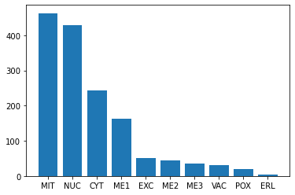

```python
# Issues with small classes

data=pd.read_csv('../Problems/Yeast-UCI/Yeast-UCI.csv')
X=data.drop(['CYT','ERL'],axis=1)
y=data['ERL']

# distribution of classes

plt.bar(y.unique(),y.value_counts());
```

```python
model=LogisticRegression()


skf = StratifiedKFold(n_splits=5)

for train_index, test_index in skf.split(X, y):
    X_train, X_test = X.iloc[train_index,:], X.iloc[test_index,:]
    y_train, y_test = y[train_index], y[test_index]
    model=LogisticRegression(max_iter=1000).fit(np.array(X_train),y_train)
    y_pred=model.predict(X_test)
    fold_loss=zero_one_loss(y_test, y_pred)
    print(fold_loss)
```

```
0.4545454545454546
0.430976430976431
0.43434343434343436
0.4949494949494949
0.43581081081081086
```

```python
def loss_by_index(X,y,train_index, test_index,model):
    X_train, X_test = X.iloc[train_index,:], X.iloc[test_index,:]
    y_train, y_test = y[train_index], y[test_index]
    model.fit(np.array(X_train),y_train)
    y_pred=model.predict(X_test)
    loss=zero_one_loss(y_test, y_pred)
    return loss
```

```python
# the for cycle with the function

for train_index, test_index in skf.split(X, y):
    X_train, X_test = X.iloc[train_index,:], X.iloc[test_index,:]
    y_train, y_test = y[train_index], y[test_index]
    model=LogisticRegression(max_iter=1000)
    fold_loss=loss_by_index(X,y,train_index, test_index,model)
    print(fold_loss)
```

```
0.4545454545454546
0.430976430976431
0.43434343434343436
0.4949494949494949
0.43581081081081086
```